# Titanic: Machine Learning from Disaster

Learning Python Pandas and scikit-learn with the Kaggle Titanic dataset. Source: https://www.kaggle.com/c/titanic-gettingStarted

## 1. Problem definition

On April 15, 1912, during her maiden voyage, the Titanic sank after colliding with an iceberg, killing 1,502 out of 2,224 passengers and crew. This analysis is focused on using machine learning methods to predict which passengers survived the tradegy. The Kaggle score is the percentage of passengers correctly predicted.

The datasets and variable descriptions are available at https://www.kaggle.com/c/titanic-gettingStarted/data.

*Note that the full dataset is available elsewhere online. If you try this challenge yourself don't get frustrated if you aren't close to 100% accuracy. There is some major overfitting happening due to people using the entire dataset. In the real world, overfitting generally leads to poor performance on data other than the training set.*

## 2. Analyze and prepare data

### Clean up the data

Import the relevant libraries.

```python
import pandas as pd
import numpy as np
from sklearn import metrics
import os
```

Check the current working directory.

```python
os.getcwd()
```

```
'C:\\Users\\206424686\\Dropbox (Personal)\\Coding\\Kaggle\\Titanic Survival Prediction'
```

Load the training dataset and view a sample.

```python
training = pd.read_csv('Data/train.csv', sep=',')
training.head(10)
```

|  | PassengerId | Survived | Pclass | Name | Sex | Age | SibSp | Parch | Ticket | Fare | Cabin | Embarked |
| --- | --- | --- | --- | --- | --- | --- | --- | --- | --- | --- | --- | --- |
| 0 | 1 | 0 | 3 | Braund, Mr. Owen Harris | male | 22 | 1 | 0 | A/5 21171 | 7.2500 | NaN | S |
| 1 | 2 | 1 | 1 | Cumings, Mrs. John Bradley (Florence Briggs Th... | female | 38 | 1 | 0 | PC 17599 | 71.2833 | C85 | C |
| 2 | 3 | 1 | 3 | Heikkinen, Miss. Laina | female | 26 | 0 | 0 | STON/O2. 3101282 | 7.9250 | NaN | S |
| 3 | 4 | 1 | 1 | Futrelle, Mrs. Jacques Heath (Lily May Peel) | female | 35 | 1 | 0 | 113803 | 53.1000 | C123 | S |
| 4 | 5 | 0 | 3 | Allen, Mr. William Henry | male | 35 | 0 | 0 | 373450 | 8.0500 | NaN | S |
| 5 | 6 | 0 | 3 | Moran, Mr. James | male | NaN | 0 | 0 | 330877 | 8.4583 | NaN | Q |
| 6 | 7 | 0 | 1 | McCarthy, Mr. Timothy J | male | 54 | 0 | 0 | 17463 | 51.8625 | E46 | S |
| 7 | 8 | 0 | 3 | Palsson, Master. Gosta Leonard | male | 2 | 3 | 1 | 349909 | 21.0750 | NaN | S |
| 8 | 9 | 1 | 3 | Johnson, Mrs. Oscar W (Elisabeth Vilhelmina Berg) | female | 27 | 0 | 2 | 347742 | 11.1333 | NaN | S |
| 9 | 10 | 1 | 2 | Nasser, Mrs. Nicholas (Adele Achem) | female | 14 | 1 | 0 | 237736 | 30.0708 | NaN | C |

The objective is to predict 'Survived' using the other variables. Looking at the above we can probably immediately drop the following:

- 'Name' - Doesn't make sense to dummy as each name is essentially unique. Also hard to imagine name alone correlates with survival rate after controlling for other proxies of social/economic status ('Pclass' and 'Fare')
- 'Ticket' - Doesn't seem useful at all...
- 'Cabin' - Doesn't seem particularly useful plus most are blank

Take a quick look at 'Cabin' to double-check.

```python
training['Cabin'].fillna(0).value_counts()
```

```
0              687
B96 B98          4
C23 C25 C27      4
G6               4
D                3
C22 C26          3
E101             3
F2               3
F33              3
E33              2
B28              2
E44              2
C123             2
C83              2
C126             2
...
C90        1
B82 B84    1
A5         1
B41        1
D47        1
D50        1
C106       1
C49        1
B73        1
A14        1
D46        1
D56        1
C50        1
C95        1
B86        1
Length: 148, dtype: int64
```

Drop the unnecessary columns before proceeding.

```python
training = training.drop(['Name', 'Ticket', 'Cabin'], axis=1)
training.head(10)
```

|  | PassengerId | Survived | Pclass | Sex | Age | SibSp | Parch | Fare | Embarked |
| --- | --- | --- | --- | --- | --- | --- | --- | --- | --- |
| 0 | 1 | 0 | 3 | male | 22 | 1 | 0 | 7.2500 | S |
| 1 | 2 | 1 | 1 | female | 38 | 1 | 0 | 71.2833 | C |
| 2 | 3 | 1 | 3 | female | 26 | 0 | 0 | 7.9250 | S |
| 3 | 4 | 1 | 1 | female | 35 | 1 | 0 | 53.1000 | S |
| 4 | 5 | 0 | 3 | male | 35 | 0 | 0 | 8.0500 | S |
| 5 | 6 | 0 | 3 | male | NaN | 0 | 0 | 8.4583 | Q |
| 6 | 7 | 0 | 1 | male | 54 | 0 | 0 | 51.8625 | S |
| 7 | 8 | 0 | 3 | male | 2 | 3 | 1 | 21.0750 | S |
| 8 | 9 | 1 | 3 | female | 27 | 0 | 2 | 11.1333 | S |
| 9 | 10 | 1 | 2 | female | 14 | 1 | 0 | 30.0708 | C |

Now take a look to see if there is any missing data.

```python
training.info()
```

```
<class 'pandas.core.frame.DataFrame'>
Int64Index: 891 entries, 0 to 890
Data columns (total 9 columns):
PassengerId    891 non-null int64
Survived       891 non-null int64
Pclass         891 non-null int64
Sex            891 non-null object
Age            714 non-null float64
SibSp          891 non-null int64
Parch          891 non-null int64
Fare           891 non-null float64
Embarked       889 non-null object
dtypes: float64(2), int64(5), object(2)
```

It appears that 'Age' and 'Embarked' have missing values. **Handling missing data could be an exercise by itself** (and we should do analysis to see if the missing rows might have a pattern) but let's just set missing quantitative values to 0 and set missing 'Embarked' values to S because it is the most frequent value.

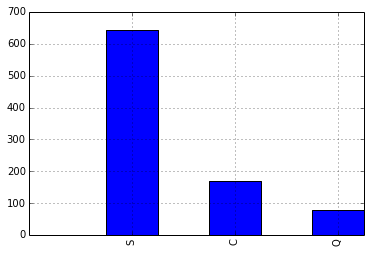

```python
training['Embarked'].value_counts().plot(kind='bar')
```

```python
training['Embarked'] = training['Embarked'].fillna('S')
training = training.fillna(0)
training.info()
```

```
<class 'pandas.core.frame.DataFrame'>
Int64Index: 891 entries, 0 to 890
Data columns (total 9 columns):
PassengerId    891 non-null int64
Survived       891 non-null int64
Pclass         891 non-null int64
Sex            891 non-null object
Age            891 non-null float64
SibSp          891 non-null int64
Parch          891 non-null int64
Fare           891 non-null float64
Embarked       891 non-null object
dtypes: float64(2), int64(5), object(2)
```

The algorithms require numerical inputs so we'll need to create dummy/indicator variables for 'Sex' and 'Embarked'.

```python
embarked_dummies = pd.get_dummies(training['Embarked'])
embarked_dummies.head(10)
```

|  | C | Q | S |
| --- | --- | --- | --- |
| 0 | 0 | 0 | 1 |
| 1 | 1 | 0 | 0 |
| 2 | 0 | 0 | 1 |
| 3 | 0 | 0 | 1 |
| 4 | 0 | 0 | 1 |
| 5 | 0 | 1 | 0 |
| 6 | 0 | 0 | 1 |
| 7 | 0 | 0 | 1 |
| 8 | 0 | 0 | 1 |
| 9 | 1 | 0 | 0 |

Join back to main dataset and make sure the dummies joined correctly by looking at the 'Embarked' value and the associated 1/0's.

```python
training = training.join(embarked_dummies)
training.head(10)
```

|  | PassengerId | Survived | Pclass | Sex | Age | SibSp | Parch | Fare | Embarked | C | Q | S |
| --- | --- | --- | --- | --- | --- | --- | --- | --- | --- | --- | --- | --- |
| 0 | 1 | 0 | 3 | male | 22 | 1 | 0 | 7.2500 | S | 0 | 0 | 1 |
| 1 | 2 | 1 | 1 | female | 38 | 1 | 0 | 71.2833 | C | 1 | 0 | 0 |
| 2 | 3 | 1 | 3 | female | 26 | 0 | 0 | 7.9250 | S | 0 | 0 | 1 |
| 3 | 4 | 1 | 1 | female | 35 | 1 | 0 | 53.1000 | S | 0 | 0 | 1 |
| 4 | 5 | 0 | 3 | male | 35 | 0 | 0 | 8.0500 | S | 0 | 0 | 1 |
| 5 | 6 | 0 | 3 | male | 0 | 0 | 0 | 8.4583 | Q | 0 | 1 | 0 |
| 6 | 7 | 0 | 1 | male | 54 | 0 | 0 | 51.8625 | S | 0 | 0 | 1 |
| 7 | 8 | 0 | 3 | male | 2 | 3 | 1 | 21.0750 | S | 0 | 0 | 1 |
| 8 | 9 | 1 | 3 | female | 27 | 0 | 2 | 11.1333 | S | 0 | 0 | 1 |
| 9 | 10 | 1 | 2 | female | 14 | 1 | 0 | 30.0708 | C | 1 | 0 | 0 |

Do the same for 'Sex' and drop the text columns.

```python
sex_dummies = pd.get_dummies(training['Sex'])
training = training.join(sex_dummies)
training = training.drop(['Embarked', 'Sex'], axis=1)
training.head(10)
```

|  | PassengerId | Survived | Pclass | Age | SibSp | Parch | Fare | C | Q | S | female | male |
| --- | --- | --- | --- | --- | --- | --- | --- | --- | --- | --- | --- | --- |
| 0 | 1 | 0 | 3 | 22 | 1 | 0 | 7.2500 | 0 | 0 | 1 | 0 | 1 |
| 1 | 2 | 1 | 1 | 38 | 1 | 0 | 71.2833 | 1 | 0 | 0 | 1 | 0 |
| 2 | 3 | 1 | 3 | 26 | 0 | 0 | 7.9250 | 0 | 0 | 1 | 1 | 0 |
| 3 | 4 | 1 | 1 | 35 | 1 | 0 | 53.1000 | 0 | 0 | 1 | 1 | 0 |
| 4 | 5 | 0 | 3 | 35 | 0 | 0 | 8.0500 | 0 | 0 | 1 | 0 | 1 |
| 5 | 6 | 0 | 3 | 0 | 0 | 0 | 8.4583 | 0 | 1 | 0 | 0 | 1 |
| 6 | 7 | 0 | 1 | 54 | 0 | 0 | 51.8625 | 0 | 0 | 1 | 0 | 1 |
| 7 | 8 | 0 | 3 | 2 | 3 | 1 | 21.0750 | 0 | 0 | 1 | 0 | 1 |
| 8 | 9 | 1 | 3 | 27 | 0 | 2 | 11.1333 | 0 | 0 | 1 | 1 | 0 |
| 9 | 10 | 1 | 2 | 14 | 1 | 0 | 30.0708 | 1 | 0 | 0 | 1 | 0 |

ALMOST done! You need to delete one column per categorical variable due to the 'dummy variable trap'. If we were to run a regression with the above dataset we would have perfect multicollinearity in some cases. This is when independent variables are highly correlated which leads to bad things... More info without a bunch of math: http://www.investopedia.com/terms/m/multicollinearity.asp

For example, 'female' and 'male' now have a -1.0 correlation because each person is tagged as only either female or male.

```python
training = training.drop(['S', 'male'], axis=1)
training.head(10)
```

|  | PassengerId | Survived | Pclass | Age | SibSp | Parch | Fare | C | Q | female |
| --- | --- | --- | --- | --- | --- | --- | --- | --- | --- | --- |
| 0 | 1 | 0 | 3 | 22 | 1 | 0 | 7.2500 | 0 | 0 | 0 |
| 1 | 2 | 1 | 1 | 38 | 1 | 0 | 71.2833 | 1 | 0 | 1 |
| 2 | 3 | 1 | 3 | 26 | 0 | 0 | 7.9250 | 0 | 0 | 1 |
| 3 | 4 | 1 | 1 | 35 | 1 | 0 | 53.1000 | 0 | 0 | 1 |
| 4 | 5 | 0 | 3 | 35 | 0 | 0 | 8.0500 | 0 | 0 | 0 |
| 5 | 6 | 0 | 3 | 0 | 0 | 0 | 8.4583 | 0 | 1 | 0 |
| 6 | 7 | 0 | 1 | 54 | 0 | 0 | 51.8625 | 0 | 0 | 0 |
| 7 | 8 | 0 | 3 | 2 | 3 | 1 | 21.0750 | 0 | 0 | 0 |
| 8 | 9 | 1 | 3 | 27 | 0 | 2 | 11.1333 | 0 | 0 | 1 |
| 9 | 10 | 1 | 2 | 14 | 1 | 0 | 30.0708 | 1 | 0 | 1 |

### Summarize the data

*Note that you generally do this before you start dropping/changing variables but I changed the order here to make the code and output cleaner.*

```python
training.describe()
```

|  | PassengerId | Survived | Pclass | Age | SibSp | Parch | Fare | C | Q | female |
| --- | --- | --- | --- | --- | --- | --- | --- | --- | --- | --- |
| count | 891.000000 | 891.000000 | 891.000000 | 891.000000 | 891.000000 | 891.000000 | 891.000000 | 891.000000 | 891.000000 | 891.000000 |
| mean | 446.000000 | 0.383838 | 2.308642 | 23.799293 | 0.523008 | 0.381594 | 32.204208 | 0.188552 | 0.086420 | 0.352413 |
| std | 257.353842 | 0.486592 | 0.836071 | 17.596074 | 1.102743 | 0.806057 | 49.693429 | 0.391372 | 0.281141 | 0.477990 |
| min | 1.000000 | 0.000000 | 1.000000 | 0.000000 | 0.000000 | 0.000000 | 0.000000 | 0.000000 | 0.000000 | 0.000000 |
| 25% | 223.500000 | 0.000000 | 2.000000 | 6.000000 | 0.000000 | 0.000000 | 7.910400 | 0.000000 | 0.000000 | 0.000000 |
| 50% | 446.000000 | 0.000000 | 3.000000 | 24.000000 | 0.000000 | 0.000000 | 14.454200 | 0.000000 | 0.000000 | 0.000000 |
| 75% | 668.500000 | 1.000000 | 3.000000 | 35.000000 | 1.000000 | 0.000000 | 31.000000 | 0.000000 | 0.000000 | 1.000000 |
| max | 891.000000 | 1.000000 | 3.000000 | 80.000000 | 8.000000 | 6.000000 | 512.329200 | 1.000000 | 1.000000 | 1.000000 |

Doesn't make sense to see 0 for 'Fare' so do a quick sanity check using a histogram. Looks good enough to leave in there...

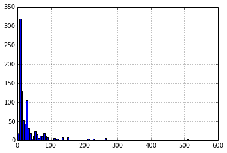

```python
training['Fare'].hist(bins=100)
```

A simple groupby to see if survival rates seem to differ by some of the variables.

```python
training['Survived'].mean()
```

```
0.38383838383838381
```

What did our model baseline just become? Hint: It's not 50/50.

```python
training['Survived'].groupby(training['female']).mean()
```

```
female
0         0.188908
1         0.742038
dtype: float64
```

**Given the short presentation time and focus on coding vs. the "best" analysis going to skip the usual histograms, correlations and scatter plots. Do not underestimate the importance of understanding your data before running models!**

## 3. Evaluate algorithms

Let's approach this as a classification problem because we'll want to predict a binary response (survived or not). For this example we'll use a general purpose ensemble algorithm (random forest).

Before we begin let's split the dataset into data (independent variables) and target (dependent variable). For scikit-learn you'll need to convert from Pandas dataframes to arrays.

```python
training_data = training.values[:,2:]
training_target = training.values[:,1]
training_target[:5]
```

```
array([ 0.,  1.,  1.,  1.,  0.])
```

Bring in the test dataset and apply the same basic transformations.

```python
test = pd.read_csv('Data/test.csv', sep=',')
test = test.drop(['Name', 'Ticket', 'Cabin'], axis=1)
test['Embarked'] = test['Embarked'].fillna(method='ffill')
test = test.fillna(0)
embarked_dummies = pd.get_dummies(test['Embarked'])
test = test.join(embarked_dummies)
sex_dummies = pd.get_dummies(test['Sex'])
test = test.join(sex_dummies)
test = test.drop(['Embarked', 'Sex'], axis=1)
test = test.drop(['S', 'male'], axis=1)
test_data = test.values
test_data[:3]
```

```
array([[ 892.    ,    3.    ,   34.5   ,    0.    ,    0.    ,    7.8292,
           0.    ,    1.    ,    0.    ],
       [ 893.    ,    3.    ,   47.    ,    1.    ,    0.    ,    7.    ,
           0.    ,    0.    ,    1.    ],
       [ 894.    ,    2.    ,   62.    ,    0.    ,    0.    ,    9.6875,
           0.    ,    1.    ,    0.    ]])
```

### Random forest

An ensemble method which creates a number of decision trees on different subsets of the dataset. A fast, multi-purpose algorithm but generally a black-box. More info: http://en.wikipedia.org/wiki/Random_forest.

```python
from sklearn.ensemble import RandomForestClassifier
rf_model = RandomForestClassifier(n_estimators = 1000)
rf_model.fit(training_data, training_target)
print(rf_model)
```

```
RandomForestClassifier(bootstrap=True, compute_importances=None,
            criterion='gini', max_depth=None, max_features='auto',
            max_leaf_nodes=None, min_density=None, min_samples_leaf=1,
            min_samples_split=2, n_estimators=1000, n_jobs=1,
            oob_score=False, random_state=None, verbose=0)
```

Make predictions on the training dataset and summarize the fit of the model. Note there is probably some overfitting as we are still within the training dataset. Will apply the algorithm to the test set for final scoring on Kaggle. Normally you'd split your dataset of known values into train/test but skipping for this demonstration as going to show cross validation instead.

```python
expected = training_target
predicted = rf_model.predict(training_data)
print(metrics.accuracy_score(expected, predicted))
print(metrics.confusion_matrix(expected, predicted))
print(metrics.roc_auc_score(expected, predicted))
```

```
0.982042648709
[[544   5]
 [ 11 331]]
0.979364394593
```

98% accuracy?!?! Is this for real?

A quick look at relative feature importance.

```python
print(rf_model.feature_importances_)
print(training.columns)
# Use np.savetxt to get header and combine so easier to read? Maybe zip the array?
```

```
[ 0.08400495  0.25249511  0.0510197   0.04516403  0.2760021   0.02157853
  0.01242843  0.25730715]
Index(['PassengerId', 'Survived', 'Pclass', 'Age', 'SibSp', 'Parch', 'Fare', 'C', 'Q', 'female'], dtype='object')
```

Hard to read but seems that 'Age', 'Fare' and 'female' are the primary model drivers.

```python
from sklearn import cross_validation
from sklearn.linear_model import LogisticRegression

num_folds = 10
num_instances = len(training_data)
kfold = cross_validation.KFold(n=num_instances, n_folds=num_folds)
model = LogisticRegression()
results = cross_validation.cross_val_score(model, training_data, training_target, cv=kfold)
print(results)
print(results.mean())
print(results.std())
```

```
[ 0.8         0.82022472  0.75280899  0.79775281  0.75280899  0.76404494
  0.75280899  0.75280899  0.86516854  0.79775281]
0.785617977528
0.0357748291993
```

Use the algorithm on the true test data and combine/export for upload to Kaggle.

```python
predicted = rf_model.predict(test_data[:,1:])
submission = np.c_[test_data[:,0].astype(int), predicted.astype(int)]
submission = pd.DataFrame(submission, columns=['PassengerId', 'Survived'])
submission.to_csv('Data/submission_rf.csv', index=False)
submission.head()
```

|  | PassengerId | Survived |
| --- | --- | --- |
| 0 | 892 | 0 |
| 1 | 893 | 0 |
| 2 | 894 | 0 |
| 3 | 895 | 1 |
| 4 | 896 | 0 |

So how'd we do? Overall a 74% accuracy at Kaggle on true test data. Not very good relative to some simple heuristics:

- A survival table created based on the proportion of survivors using gender, their ticket class and the price they paid for their ticket (78% accurate)
- Assume that if the passenger is female then survives, if not then does not (77% accurate)
- Assume that all did not survive (62% accurate; our baseline)

Remember how important it is to understand your data?

## 4. Improve results

What could we have done differently? This is always an interative process and a few things come to mind:

- Instead of setting missing 'Age' values to 0 try mean/median of their class (we saw that 'Age' was relatively one of the most important variables)
- Instead of setting missing 'Fare' in the true test dataset to 0 try mean/median of their class (notice it wasn't blank in our testing dataset so we didn't even think about it!)
- Do a much better job of analyzing and visualizing before any feature engineering and/or variable transformations
- Run a logistic regression model or similar to better understand the relationships. Much better insight into coefficient behavior and variable significance
- Anything else?